# What do I sound like online? - GMail vs. Facebook.

### A machine-learning driven exploration of online speech patterns

In this project, I want to explore several questions about my online speech patterns, as well as the speech patterns of other people. I'll be asking five main questions:

1. What words do I use that differentiate myself the greatest from my friends over Facebook Messenger?
2. Which people do I talk to on Facebook Messenger - and how frequently do I talk to each of them? Do I talk to some significantly more than others?
3. Do I use different words to talk to different people on Facebook?
4. How do I express myself differently via e-mail as opposed to via Facebook Messenger?
5. Do the emails I send contain more words on average than the messages I send on Facebook?

To answer these questions, I'll be using two primary source of data:

1. Facebook messenger data
2. GMail message data

In this notebook, I'll be exploring the differences between my email and Facebook messenger data. I'll attempt to answer the last two questions:

1. How do I express myself differently via e-mail as opposed to via Facebook Messenger?
2. Do the emails I send contain more words on average than the messages I send on Facebook?

**Contents**

1. Importing and parsing data
2. Do I talk differently on Facebook vs. GMail?
3. Are my emails longer than my messages?
4. Conclusion

## 1. Importing data

```python
import json

with open("data/fb_sample_data.json", "r") as f:
    fb_data = json.load(f)

with open("data/gmail_data.json", "r") as f:
    gmail_data = json.load(f)
```

```python
import pandas as pd
```

```python
fb = pd.DataFrame(fb_data)
fb_text = fb["text"].tolist()
fb_text[:5]
```

```
['Unless you think the tournament will start p late (like past 4)',
 'starter',
 'https://docs.google.com/document/d/1sWr2J5QMr2J0l1LN9Ve233-3qEs3UmsEKwTg3Yp2zxY/edit',
 'i guess :(',
 "we're voting yes"]
```

```python
gmail = pd.DataFrame(gmail_data)
gmail_text = gmail["Message"].tolist()
gmail_text[:2]
```

```
["Hey Chandra!!  I'm super sorry I just don't have $30 in notes - but can I venmo you? Or if I come over would you have change for two $20s?  Best, Angelina",
 'Hi Chandra!  I just left $40 under your door. In this case, can I change my order quantity from 3 boxes to 4? Thanks!  Best, Angelina']
```

```python
all_text = fb_text + gmail_text
all_labels = ["fb"]*len(fb_text) + ["gmail"]*len(gmail_text)
```

```python
import numpy as np

all_data = list(zip(all_labels, all_text))
np.random.shuffle(all_data)
all_labels, all_text = zip(*all_data)
```

```python
halfway = int(len(all_text)/2)
train_text = all_text[:halfway]
train_labels = all_labels[:halfway]
test_text = all_text[halfway:]
test_labels = all_labels[halfway:]
```

```python
train_labels[:20]
```

```
('fb',
 'fb',
 'fb',
 'fb',
 'fb',
 'fb',
 'fb',
 'fb',
 'fb',
 'fb',
 'fb',
 'fb',
 'fb',
 'fb',
 'fb',
 'fb',
 'fb',
 'fb',
 'fb',
 'fb')
```

## 2. Do I talk differently on Facebook as compared to on email?

```python
from sklearn.feature_extraction.text import CountVectorizer
from sklearn.naive_bayes import MultinomialNB
```

```python
vectorizer = CountVectorizer()
x_train = vectorizer.fit_transform(train_text)

classifier = MultinomialNB()
classifier.fit(x_train, train_labels)
```

```
MultinomialNB(alpha=1.0, class_prior=None, fit_prior=True)
```

Let's find the accuracy rate of this model.

```python
test_vector = vectorizer.transform(test_text)
accuracy = 0
for i, actual_label in enumerate(test_labels):
    case = test_vector[i]
    predicted_label = classifier.predict(case[0])[0]
    if predicted_label == actual_label:
        accuracy += 1

print("{} out of {} correct, with an accuracy rate of {}%".format(
    accuracy, len(test_labels), round(100*accuracy/len(test_labels))
))
```

```
5576 out of 5948 correct, with an accuracy rate of 94%
```

It looks like our model is really successful! Let's see which features are the most successful at making predictions.

```python
feature_names = vectorizer.get_feature_names()
coefs = sorted(zip(classifier.coef_[0], feature_names), reverse=True)
print("Features for class {}".format(classifier.classes_[1]))
top_words = []
for i in range(42):
    coef, word = coefs[i]
    top_words.append(word)
    print("{}\t{}".format(round(coef, 4), word))
```

```
Features for class gmail
-3.4131	the
-3.5036	to
-3.7733	you
-4.0367	and
-4.1907	for
-4.2776	angelina
-4.3874	in
-4.3887	of
-4.6072	best
-4.6813	be
-4.7177	that
-4.8828	this
-4.9094	on
-4.9139	if
-4.9139	have
-4.939	hi
-4.972	my
-5.021	me
-5.0542	so
-5.0752	wellesley
-5.0939	it
-5.1076	is
-5.1697	all
-5.2329	ll
-5.2454	at
-5.2517	we
-5.3515	with
-5.3871	your
-5.424	but
-5.494	would
-5.5564	know
-5.5607	about
-5.5737	college
-5.5869	was
-5.6322	as
-5.6368	can
-5.6368	are
-5.6747	thank
-5.6796	li
-5.7293	just
-5.7293	857
-5.7293	19
```

Let's generate a wordcloud to showcase some of these features.

```python
import matplotlib.pyplot as plt
%matplotlib inline
from wordcloud import WordCloud
```

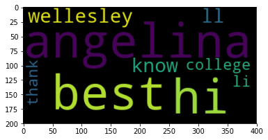

```python
wordcloud = WordCloud().generate(" ".join(top_words))
plt.imshow(wordcloud, interpolation="bilinear")
```

## 3. Are my emails longer than my messages?

It certainly feels like it to me, but it'd be interesting to test this and to know for sure!

```python
len_fb = [len(msg.split()) for msg in fb_text]
len_gmail = [len(msg.split()) for msg in gmail_text]
```

```python
len_fb[:5]
```

```
[12, 1, 1, 3, 3]
```

```python
len_gmail[:5]
```

```
[32, 26, 27, 6, 23]
```

It certainly seems from the above sample that we'll get a statistically significant result here.

```python
import scipy.stats as stats
```

```python
stats.ttest_ind(len_fb, len_gmail, equal_var=False)
```

```
Ttest_indResult(statistic=-30.655856105792072, pvalue=2.8413205624931658e-168)
```

Sure enough, our p-value is vanishingly tiny. Our test statistic tells us that gmail messages are much much longer than facebook ones. We can find out by how much on average:

```python
print("Average gmail message length: {}".format(np.mean(len_gmail)))
```

```
Average gmail message length: 59.43934599156118
```

```python
print("Average fb message length: {}".format(np.mean(len_fb)))
```

```
Average fb message length: 7.4737
```

```python
import seaborn as sns
```

```python
sns.set(color_codes=True)
```

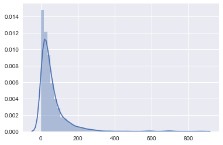

```python
sns.distplot(len_gmail)
```

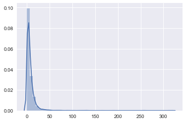

```python
sns.distplot(len_fb)
```

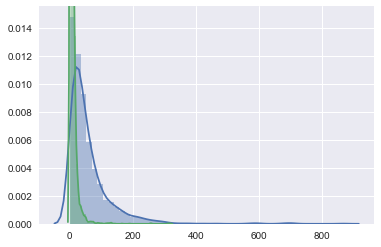

```python
sns.distplot(len_gmail)
sns.distplot(len_fb)
```

## 4. Conclusion

It's interesting to me that one of the primary words that differentiates my email messages from my facebook messages is the use of my full name ("Angelina Li") - I think this is reflective of one of the biggest perceptive differences between email and messages - email fells like a much more formal medium.

It's unsurprising that my email messages and facebook messages differ in length on average! Again, because it's a more formal medium, email messages often contain more information than facebook messages.